# GRASS 101

Basic notions, interfaces and temporal framework

Author

Veronica Andreo

Published

May 21, 2026

## What is GRASS?

GRASS is a **free and open-source geospatial processing engine** for advanced analysis and visualization of raster, vector, 3D, and temporal data. With more than 500 tools covering terrain modeling, hydrology, imagery processing, time series analysis, and ecological modeling, it is a computational powerhouse built for science.

Unlike traditional desktop GIS applications, GRASS is designed as an **engine with many interfaces**:

- **Command line** — run tools directly in a terminal
- **Python API** (`grass.script`, `grass.jupyter`) — script workflows, run in Jupyter Notebooks or Google Colab
- **R** (`rgrass` package) — combine GRASS algorithms with R’s statistical ecosystem
- **Graphical user interface (GUI)** — interactive exploration and map display

This makes GRASS a natural fit for **reproducible, scripted geospatial workflows** and easy to integrate with the broader data science stack — NumPy, pandas, scikit-learn, matplotlib, and more.

In this session we will use GRASS through **Jupyter Notebooks on Google Colab**, so no local installation is needed.

## Projects and data organisation

GRASS organises data in a simple hierarchy:

- **Project**: a folder for data sharing a common coordinate reference system (CRS), ensuring spatial consistency across all datasets.
- **Mapset**: a sub-folder within a project for organising analyses or access permissions. Every project has a special *PERMANENT* mapset for source datasets accessible to all other mapsets.

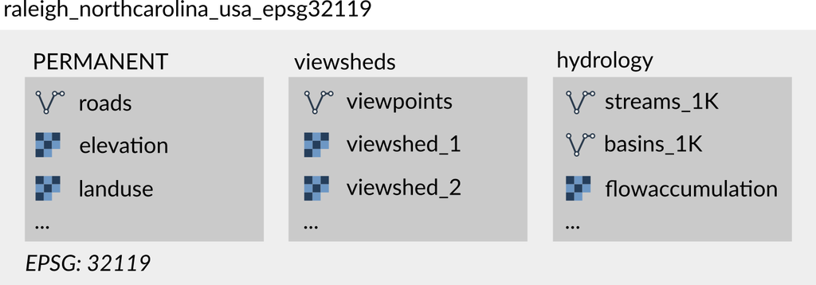

**Note**

See https://grass.osgeo.org/grass85/manuals/grass_projects.html for further details.

## Computational region

A very useful concept when working with raster data is that of the **computational region**. It refers to the *boundaries and spatial resolution of the analysis area*. The computational region can be defined and modified with the tool [g.region](https://grass.osgeo.org/grass-stable/manuals/g.region.html) to the extent of a vector map, a raster or manually to some area of interest. The *output raster maps* will have an extent and spatial resolution equal to the computational region, while vector maps are always processed at their original extent.

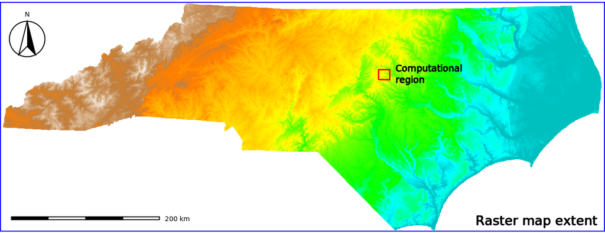

**Note**

For more details, see the wiki on [Computational Region](https://grasswiki.osgeo.org/wiki/Computational_region).

## Tools

GRASS has more than [500 tools](https://grass.osgeo.org/grass-stable/manuals/full_index.html) for the most varied tasks:

| Prefix | Function class | Type of command | Example |
| --- | --- | --- | --- |
| [g.*](https://grass.osgeo.org/grass-stable/manuals/full_index.html#g) | general | general data management | [g.rename](https://grass.osgeo.org/grass-stable/manuals/g.rename.html): renames map |
| [d.*](https://grass.osgeo.org/grass-stable/manuals/full_index.html#d) | display | graphical output | [d.rast](https://grass.osgeo.org/grass-stable/manuals/d.rast.html): display raster map |
| [r.*](https://grass.osgeo.org/grass-stable/manuals/full_index.html#r) | raster | raster processing | [r.mapcalc](https://grass.osgeo.org/grass-stable/manuals/r.mapcalc.html): map algebra |
| [v.*](https://grass.osgeo.org/grass-stable/manuals/full_index.html#r) | vector | vector processing | [v.clean](https://grass.osgeo.org/grass-stable/manuals/v.clean.html): topological cleaning |
| [i.*](https://grass.osgeo.org/grass-stable/manuals/full_index.html#i) | imagery | imagery processing | [i.pca](https://grass.osgeo.org/grass-stable/manuals/i.pca.html): Principal Components Analysis on imagery group |
| [r3.*](https://grass.osgeo.org/grass-stable/manuals/full_index.html#r3) | voxel | 3D raster processing | [r3.stats](https://grass.osgeo.org/grass-stable/manuals/r3.stats.html): voxel statistics |
| [db.*](https://grass.osgeo.org/grass-stable/manuals/full_index.html#db) | database | database management | [db.select](https://grass.osgeo.org/grass-stable/manuals/db.select.html): select value(s) from table |
| [ps.*](https://grass.osgeo.org/grass-stable/manuals/full_index.html#ps) | postscript | PostScript map creation | [ps.map](https://grass.osgeo.org/grass-stable/manuals/ps.map.html): PostScript map creation |
| [t.*](https://grass.osgeo.org/grass-stable/manuals/full_index.html#t) | temporal | space-time datasets | [t.rast.aggregate](https://grass.osgeo.org/grass-stable/manuals/t.rast.aggregate.html): raster time series aggregation |

Extensions or [**add-ons**](https://grass.osgeo.org/grass-stable/manuals/addons/) can be installed from the [central GitHub repository](https://github.com/OSGeo/grass-addons) or from *other users’ GitHub* (or similar repositories) using [g.extension](https://grass.osgeo.org/grass-stable/manuals/g.extension.html). For example:

```bash
 # install an extension from the GRASS repository
 g.extension extension=r.hants

 # install an extension from another GitHub repository
 g.extension extension=r.change.stats \
   url=https://github.com/mundialis/r.change.stats
```

There are different Python libraries delivered with GRASS, we’ll use 2 of them:

- `grass.script` which provides Python interface to launch GRASS modules in scripts
- `grass.jupyter` which offers classes and setup functions for running GRASS in Jupyter Notebooks

Other Python libraries delivered with GRASS include: tools, pygrass, the temporal framework, and the testing framework, among others.

We can use Python within GRASS GUI, within Jupyter notebooks, or from our preferred IDE. See the options within the GUI:

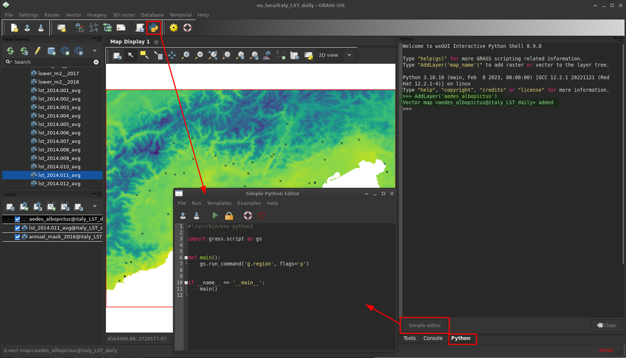

**Note**

See the [**Get started with GRASS & Python in Jupyter Notebooks**](https://grass-tutorials.osgeo.org/content/tutorials/get_started/fast_track_grass_and_python.html) tutorial for further details.

## GRASS + through `rgrass` package

The rgrass package allows us to interact with GRASS tools (and data) serving as an interface between GRASS and R.

[figure not shown]

**Note**

See the [**Get started with GRASS & R: the rgrass package**](https://grass-tutorials.osgeo.org/content/tutorials/get_started/fast_track_grass_and_R.html) tutorial for further details.

# GRASS HELP!!!

- [GRASS website](https://grass.osgeo.org/)
- [GRASS documentation](https://grass.osgeo.org/grass-stable/manuals/index.html)
- [GRASS tutorials](https://grass-tutorials.osgeo.org/)
- [g.manual](https://grass.osgeo.org/grass-stable/manuals/g.manual.html): in the main GUI under Help or just pressing *F1*
- `--help` or `--h` flag after the tool name in the terminal
- GRASS Gitter chat: https://gitter.im/grassgis/community
- GRASS on Discourse: https://discourse.osgeo.org/c/grass/grass-user/70